# La política de la corrupción

Sesión 13: ¿Tecnología contra la corrupción? Algoritmos, satélites y los límites de la detección

Bogdan G. Popescu

bgpopescu@tec.mx

Tecnológico de Monterrey

## Hoy

**¿La tecnología puede exhibir o prevenir la corrupción?** Tres casos, tres preguntas:

1. **México.** ¿Puede un algoritmo encontrar los contratos sospechosos que un equipo pequeño de auditoría dejaría pasar?
2. **India.** ¿Qué pasa cuando los vigilados descubren exactamente cómo se les está midiendo?
3. **Autocracias.** ¿Unos datos que el gobierno no controla pueden sorprenderlo exagerando sus propios logros?

Una misma idea atraviesa los tres casos:

> La tecnología puede volver los actos indebidos mucho más fáciles de **detectar**. Que además los vuelva *menos frecuentes* depende de quién tenga el **incentivo** y el **poder** de actuar.

# I. ¿Qué hace que funcione una innovación anticorrupción?

Imagen: sala de servidores, BalticServers.com, CC BY-SA 3.0, vía Wikimedia Commons.

## ¿Qué tiene que cambiar una innovación?

Imaginemos que un gobierno pone en marcha un sistema de inteligencia artificial que marca contratos públicos sospechosos. **¿De verdad va a bajar la corrupción?**

Para responder, primero hay que entender qué crea las oportunidades de corrupción.

> **más monopolio + más discrecionalidad − menos rendición de cuentas = más riesgo de corrupción**

Klitgaard lo escribe como **C = M + D − A** — la fórmula abreviada de la sesión 3.

## Cuatro preguntas para cualquier innovación

1. **¿Ataca alguna causa de la corrupción?**
   - Más competencia, menos discrecionalidad, más rendición de cuentas.
2. **¿Alguien puede actuar con lo que revela?**
   - Una empresa que pierde impugna el fallo — o nadie hace nada, porque todos dan por hecho que hay corrupción.
3. **¿Se puede manipular, o usar en contra de la gente?**
   - Los funcionarios se esconden. Los gobiernos apuntan la herramienta contra sus opositores.
4. **¿De verdad baja la corrupción?**
   - Menos contratos arreglados, no más alertas.

## Tres cosas pueden pasar después

```
%%{init: {"theme":"base","htmlLabels":false,"flowchart":{"useMaxWidth":true,"htmlLabels":false,"wrappingWidth":420,"nodeSpacing":30,"rankSpacing":95,"curve":"basis"},"themeVariables":{"fontSize":"22px","fontFamily":"Arial, Helvetica, sans-serif","lineColor":"#334155","primaryColor":"#eef2f5","primar…
flowchart LR
  T["INFORMACIÓN NUEVA<br/>un portal, un algoritmo,<br/>un satélite"]
  A["ALGUIEN ACTÚA<br/>Los actos indebidos se vuelven<br/>más difíciles o más riesgosos"]
  B["NADIE PUEDE ACTUAR<br/>Mejor registro,<br/>el mismo mundo"]
  C["LOS VIGILADOS SE ADAPTAN<br/>El número mejora,<br/>el problema no"]
  T --> A
  T --> B
  T --> C
  classDef tool fill:#4a7c6f,stroke:#2f5349,stroke-width:2px,color:#ffffff;
  classDef good fill:#e3eee9,stroke:#4a7c6f,stroke-width:2.5px,color:#1e293b;
  classDef bad fill:#f6e7e1,stroke:#b44527,stroke-width:2.5px,color:#1e293b;
  class T tool; class A good; class B,C bad;
```

**México apunta a la primera rama; Punjab cayó en la tercera.** La de en medio se ve bien en papel.

Marco adaptado de Adam y Fazekas (2021).

# II. Aprendizaje automático en México

**Preguntas 2 y 4:** ¿alguien puede actuar con lo que revelan los datos? ¿Y detectar mejor de verdad reduce la corrupción?

## Te toca auditar. ¿Por dónde empiezas?

- El gobierno firma **miles de contratos** al año. Carreteras, computadoras, medicinas, desayunos escolares.
- Algunos son corruptos. Un funcionario favorece discretamente a una empresa y recibe algo a cambio.
- **Tu trabajo:** encontrar esos contratos.
- **Tu problema:** son millones y tu equipo es chico.

Entonces: **¿cuáles abres primero?**

## Primera respuesta: buscar señales de alerta

Quienes investigan siempre han usado **señales de alerta** (*red flags*): rasgos de un contrato que sugieren que algo salió mal.

1. **Solo una empresa presenta oferta.** Quizá nadie más se enteró. Quizá nadie más era bienvenido.
2. **El contrato nunca se publica.** Las empresas rivales nunca se enteran de que existe la oportunidad.
3. **Los licitantes tienen muy poco tiempo para prepararse.** Solo una empresa avisada con anticipación podía estar lista.
4. **El precio está fuera de mercado.** Las cifras parecen construidas, no costeadas.

Una señal de alerta es **una razón para revisar**, no la prueba de un delito.

Fuente: Fazekas, Tóth y King (2016); lista de indicadores según el resumen de Medina-Hernández et al. (2026).

## Las señales de alerta fallan en los dos sentidos

1. **Un contrato honesto puede verse sospechoso.** Un solo oferente — porque solo una empresa fabrica esa cosa.
2. **Un contrato corrupto puede verse perfectamente normal.** Tres oferentes — que acordaron de antemano cuál de ellos iba a ganar.
3. **Y el expediente suele llegar demasiado tarde.** Publicar los detalles *antes* del fallo va de la mano con menos oferente único. Publicarlos después, no.

**La idea:** ¿podría una máquina leerlos todos — y detectar patrones que las reglas simples no ven?

Resultado sobre el momento de publicación: Bauhr, Czibik, de Fine Licht y Fazekas (2020), con 3.5 millones de contratos europeos. Esa es la pregunta 2: la información solo muerde si todavía hay alguien que pueda actuar.

## ¿Cómo le enseñamos a una máquina a detectar un contrato sospechoso?

Empecemos con una empresa. El gobierno mexicano le compra computadoras a la **Empresa A**.

1. **Una base de datos pública registra la compra.** CompraNet dice que la Empresa A ganó el contrato — de qué dependencia y por cuánto.
2. **Otra lista registra las sanciones.** Las autoridades mexicanas ya sancionaron a la Empresa A por conducta indebida.
3. **Junta las dos.** Un contrato público fue a dar a una empresa que el propio Estado sancionó.

Eso hace que **valga la pena abrir** el contrato. No lo vuelve corrupto.

Ejemplo ilustrativo. Las listas de sancionados vienen del SAT y de la SFP, ambas independientes de quienes compran. Fuente: Medina-Hernández, Kertész y Fazekas (2026).

## Pero hay un problema

Ahora haz lo mismo con **2.3 millones de contratos**.

1. **1,690 empresas sancionadas aparecen en los registros de contratos.** Sus contratos nos muestran cómo se ve el riesgo.
2. **¿Y todas las demás?** Algunas son honestas. A otras simplemente nunca las agarraron.
3. **Así que no podemos separar los contratos en “corruptos” y “honestos”.** Tenemos contratos ligados a sanciones y contratos de estatus desconocido — ninguno certificado como limpio.

**La solución: aprendizaje positivo–no etiquetado.** El algoritmo aprende cómo se ven los proveedores ligados a sanciones **sin suponer que todos los demás son honestos**.

Fuente: Medina-Hernández, Kertész y Fazekas (2026). 12,373 empresas están en las dos listas de sancionados; 1,690 de ellas ganaron contratos federales entre 2011 y 2022. Las sanciones se aplican a empresas, no a contratos individuales.

## ¿Y si el contrato se ve perfectamente normal?

Estás investigando un contrato. La Dependencia B le compra computadoras al Proveedor 2.

1. **Nada se ve sospechoso.** Licitación abierta, tres oferentes, precio de mercado. No se activa ninguna señal de alerta — lo cual no es lo mismo que decir que no haya nada mal.
2. **Ahora mira las otras dependencias.** La Dependencia C también le compra a los Proveedores 2, 3 y 4. El mismo grupito siempre gana.
3. **¿Eso es corrupción?** No necesariamente — quizá son las empresas serias de ese mercado. Pero es una pregunta que ningún contrato por separado podía plantear.

**El cambio:** dejar de leer los contratos de uno en uno. Ver **quién le compra a quién** en todo el mercado.

## La posición en la red le gana a la alerta

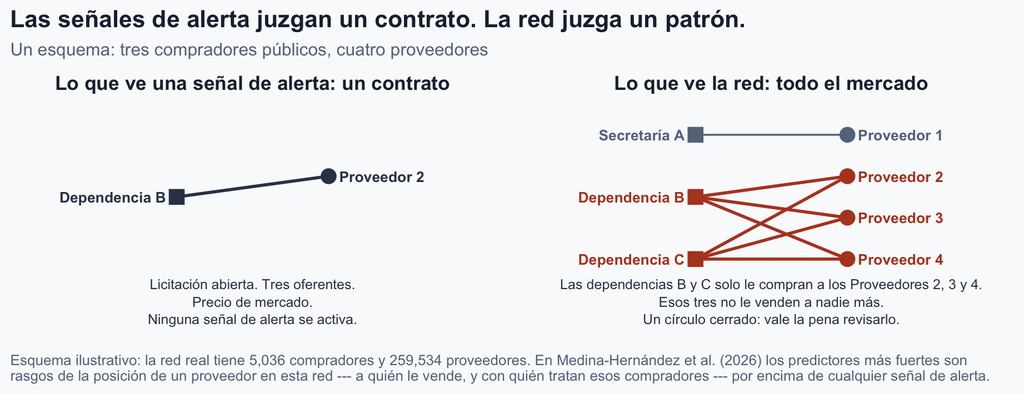

- **Izquierda:** un contrato. Nada destaca.
- **Derecha:** los mismos tres proveedores en dos dependencias — un patrón que ningún contrato aislado podía mostrar.
- Un patrón de red es **una pista, no una prueba**.

## ¿De verdad sirve el modelo?

Los investigadores ordenaron los **2.3 millones** de contratos, del más sospechoso al menos. Tu equipo de auditoría alcanza a abrir **100**. **Anota los dos números antes de la siguiente diapositiva.**

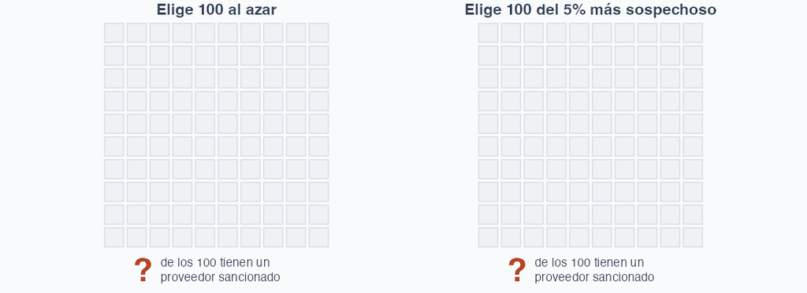

## 100 auditorías, dos formas de elegir

[figure not shown]

**Seis veces mejor — en lo alto de la lista.** Y aun así es solo una lista de sospechosos: **detectar mejor no significa que haya menos corrupción.**

Fuente: Medina-Hernández, Kertész y Fazekas (2026): 20% de precisión robusta en el 5% más alto, unas seis veces más que elegir al azar. Medido contra contratos ligados a sanciones en datos históricos, no en una auditoría real. Con otra medida — la ganancia promedio en todo el ordenamiento — el índice de señales de alerta sale peor que el azar.

## ¿Entonces una máquina puede detener la corrupción?

1. **Lo que sí puede hacer.** Decirle a un equipo pequeño de auditoría qué contratos abrir primero — seis veces mejor que el azar en lo alto de la lista.
2. **Lo que no puede hacer.** Probar que algún contrato sea corrupto. Ni garantizar que la corrupción baje.
3. **Y un problema más de fondo.** Aprendió de sanciones pasadas, y las sanciones siguen a las auditorías. Las licitaciones abiertas se auditan más que las adjudicaciones directas. Así que el modelo aprende en parte *dónde ya buscan* los investigadores — y hereda sus puntos ciegos.

> Un detector entrenado con el castigo del pasado hereda los puntos ciegos del pasado.

Fuente: Medina-Hernández et al. (2026), discusión del sesgo de etiquetado por tipo de procedimiento. La calificación es una hipótesis sobre a quién investigar, nunca un hallazgo.

## ¿Y entonces?

**México mostró la promesa.** Una máquina puede decirle a quien investiga dónde buscar. Alguien todavía tiene que buscar, y actuar.

¿Qué pasa cuando los vigilados saben exactamente **cómo** se les vigila?

¿Pueden cambiar su conducta para que no los atrapen — sin cambiar lo que en realidad hacen?

**Sigue: India.**

# III. Cuando la medida se vuelve el objetivo

**Pregunta 3:** ¿se puede manipular la medida?

Imagen: humo sobre el noroeste de India, NASA Earth Observatory (VIIRS), 2024, dominio público.

## Dónde queda Punjab

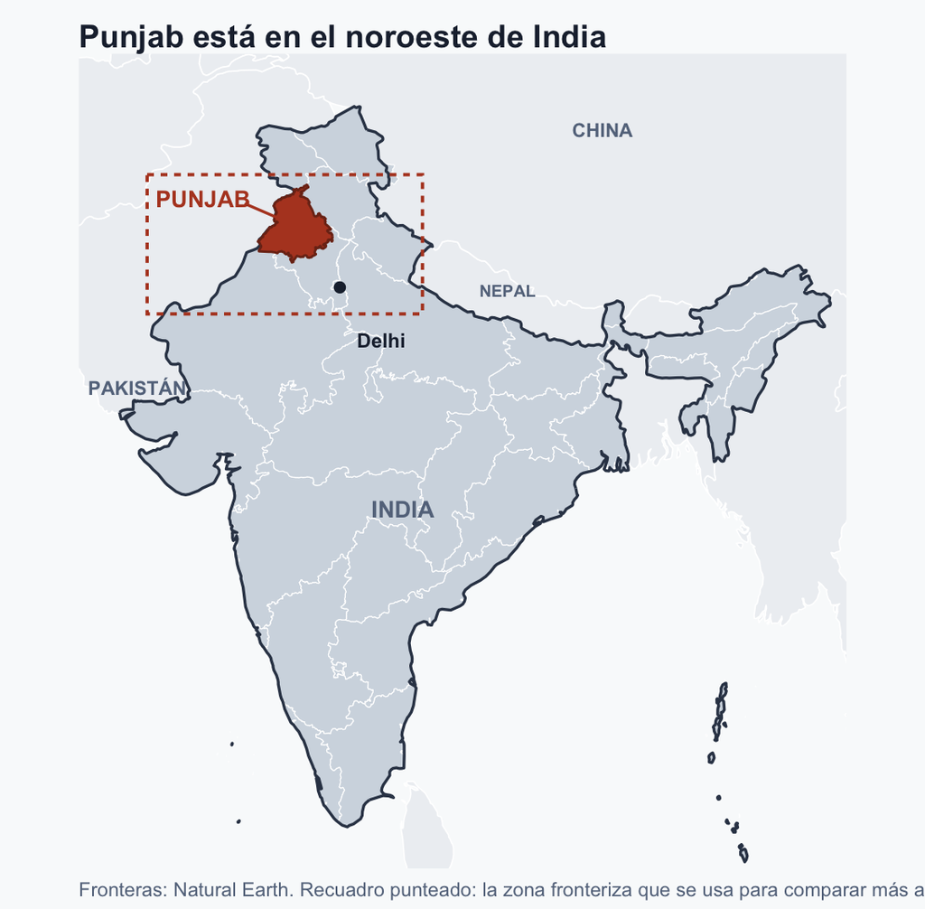

- Un estado agrícola en la **frontera con Pakistán** — alrededor del 1.5% del territorio de India
- Dos cosechas al año: **arroz en verano, trigo en invierno**. Lo que queda de la paja de arroz se llama **rastrojo**
- Sus campos quedan **200–300 km al noroeste de Delhi**, y el viento le manda a la capital casi todo el humo agrícola que llega cada invierno

## Por qué queman, y por qué nadie los detuvo

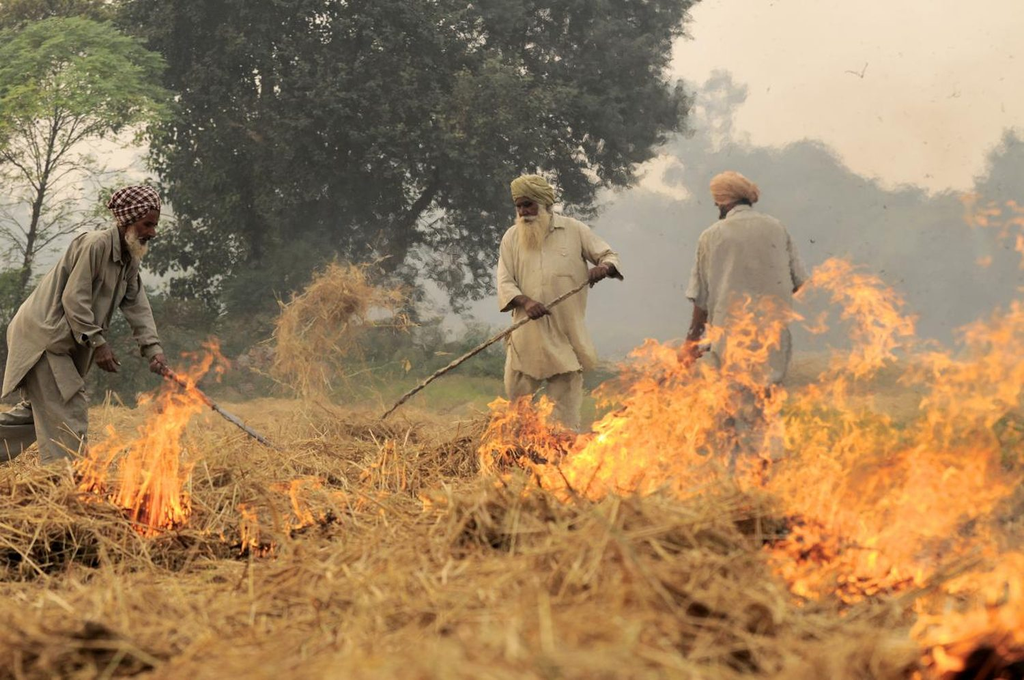

- El arroz se corta en octubre; el trigo tiene que sembrarse **en cuestión de semanas**
- Quemar limpia una parcela en un día — la maquinaria tarda más y cuesta más
- El Tribunal Verde Nacional de India lo prohibió en **2015**
- La prohibición quedó en el papel: los agricultores de Punjab tienen mucho peso político

**El problema:** ¿cómo detienes a cientos de miles de agricultores que hacen algo rápido, barato y que ya es ilegal?

Foto: Neil Palmer (CIAT), 2011, CC BY-SA 2.0, vía Wikimedia Commons. Fuente: Dasgupta (2026).

## 2022: los incendios reciben una meta

```
%%{init: {"theme":"base","htmlLabels":false,"flowchart":{"useMaxWidth":true,"htmlLabels":false,"wrappingWidth":400,"nodeSpacing":95,"rankSpacing":55,"curve":"basis"},"themeVariables":{"fontSize":"20px","fontFamily":"Arial, Helvetica, sans-serif","lineColor":"#334155","primaryColor":"#eef2f5","primar…
flowchart LR
  N["LOS SATÉLITES VEN LOS INCENDIOS<br/>Las parcelas que arden cada día,<br/>enviadas como puntos en un mapa"]
  V["UN FUNCIONARIO DE ALDEA DEBE ACTUAR<br/>Ir a la parcela, fotografiarla,<br/>levantar una multa"]
  D["A UN JEFE DE DISTRITO LO CALIFICAN<br/>Meta: 50% menos<br/>incendios detectados"]
  N --> V --> D
  classDef tool fill:#4a7c6f,stroke:#2f5349,stroke-width:2px,color:#ffffff;
  classDef mid fill:#eef2f5,stroke:#334155,stroke-width:1.5px,color:#1e293b;
  classDef gate fill:#b7943a,stroke:#7d6222,stroke-width:2.5px,color:#1e293b;
  class N tool; class V mid; class D gate;
```

Un mismo partido gobernaba ya Delhi y Punjab — era dueño del humo y del aire que ese humo arruinaba. Declaró cero tolerancia y convirtió el conteo satelital en una **meta de desempeño**.

**La expectativa:** si un incendio se ve desde el espacio, la quema se acaba.

Fuente: Dasgupta (2026). A los distritos se les pidió reducir 50% los incendios detectados respecto de su línea base de 2022. Alrededor de 8,000 funcionarios de aldea; podían ser suspendidos si había incendios repetidos sin sanción.

## Los incendios desaparecieron. ¿Y el humo?

Para 2024 Punjab registró **10,909** incendios — unos 70% menos que en 2023 y el nivel más bajo del registro satelital. El gobierno lo celebró.

**PM2.5 es contaminación del aire muy fina:** cualquier partícula de menos de 2.5 milésimas de milímetro, humo y hollín incluidos. Lo bastante pequeña para pasar de la nariz y la garganta a los pulmones, y de ahí a la sangre.

La guía de la OMS para un *solo día* es **15**. El promedio *mensual* de Delhi rebasa **200**.

## Los incendios desaparecieron. ¿Y el humo?

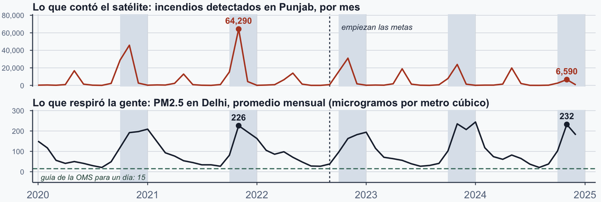

**Coméntalo con quien tengas al lado:** los incendios bajaron y el humo no. ¿Qué podría explicarlo?

Sombreado: la temporada de octubre a diciembre a la que apuntó la política; los picos más chicos de primavera quedan fuera. Línea vertical punteada: empiezan las metas, septiembre de 2022. Línea verde punteada: guía de la OMS. Redibujado de Dasgupta (2026), Fig. 2 — VIIRS y PM2.5 de la embajada de Estados Unidos en Delhi, leídos de la figura, así que son cercanos pero no exactos. El aire de Delhi tiene otras fuentes también.

## Los satélites tienen horario de oficina

Imagina una cámara de velocidad que solo se enciende a la hora de la comida.

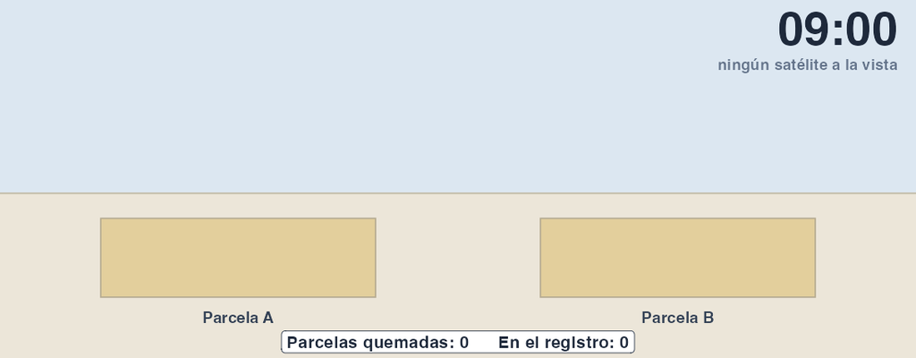

- Una quema dura **dos o tres horas**. Si la prendes a media tarde, ya es ceniza fría cuando algo vuelve a pasar por encima.
- Así que la meta eran los incendios **detectados**. No los incendios.

Esquema. Varios satélites cruzan en la ventana de 10:30 a 13:30; la animación manda uno solo. Fuente: Dasgupta (2026).

## Una parcela, cinco días después

8 de noviembre de 2021 — ardiendo Punjab, 31.1°N 74.6°E

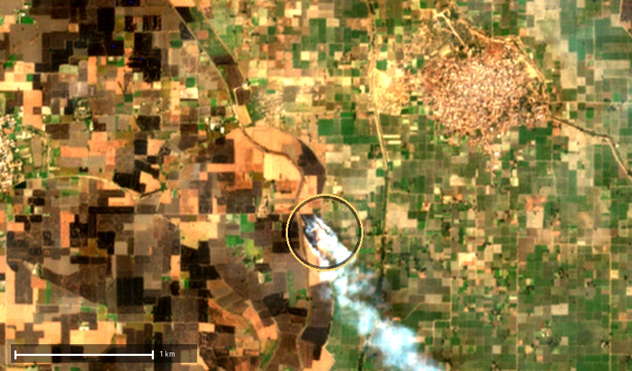

Humo blanco sobre la parcela marcada.

13 de noviembre de 2021 — quemada El mismo círculo, la misma parcela

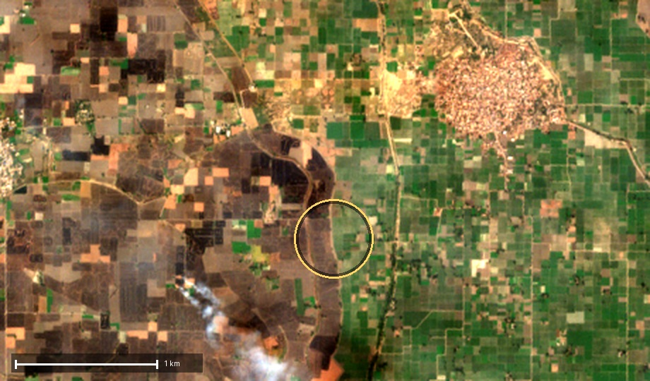

Ya no hay fuego: el suelo quedó gris oscuro.

**La llama dura horas. La huella dura semanas.** Un incendio cuenta solo si algo estaba encima mientras ardía; la cicatriz sigue ahí después. Así encuentra Dasgupta los incendios que faltan.

Color verdadero, como lo vería el ojo desde la órbita. Sentinel-2, 10 m por pixel, 4.6 km de ancho. Contiene datos modificados de Copernicus Sentinel (2021) — antes de que empezaran las metas.

## ¿Por qué ayudarían los funcionarios a esconder las quemas?

Los horarios de paso son públicos. Un agricultor con unas cuantas hectáreas no los va a consultar.

1. **Hacer cumplir la ley significaba confrontar a los vecinos.** El funcionario de incendios vive en la aldea. Los agricultores se juntaban a amenazarlo.
2. **El jefe de distrito necesitaba que bajara el conteo.** En el servicio civil indio, los puestos y los ascensos dependen de verse eficaz.
3. **Así que había una salida más fácil.** Avisarles a los agricultores cuándo pasa el satélite. El conteo baja y nadie se confronta.

**A nadie le han comprobado que lo hiciera.** Lo que muestra la evidencia es el incentivo, y un patrón de incendios escondidos que encaja con él.

Y fíjate a quién estaban midiendo: no a los agricultores, sino a los **funcionarios**.

Fuente: Dasgupta (2026), con entrevistas a funcionarios de Punjab; el artículo trata al jefe de distrito y a los funcionarios de aldea como una sola unidad de decisión. Es un mecanismo plausible y consistente con la evidencia, no una conspiración observada directamente.

## ¿Comparado con qué?

Supongamos que los incendios bajaron en todas partes ese año porque el clima fue distinto. ¿Cómo sabríamos que las metas de Punjab sirvieron de algo?

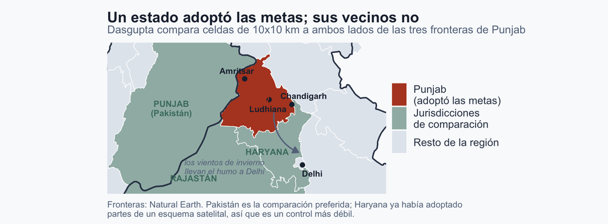

**Mismo clima, mismos suelos, mismos cultivos — distinta política.** ¿Bajaron los incendios en Punjab más de lo que bajaron justo del otro lado de la frontera?

## Por cada 100 incendios que desaparecieron, unos 22 de verdad se evitaron

Los investigadores compararon lo que detectaron los satélites con lo que dicen las cicatrices de quema que de verdad pasó.

**Imagina 100 incendios que desaparecen del registro oficial de Punjab.**

A dónde se fue en realidad la caída oficial

| Qué pasó con esos 100 incendios | Unos |
| --- | --- |
| **De verdad se evitaron** — la parcela no se quemó | **22** |
| **Se quemaron igual** — solo que sin nadie mirando | **78** |

**Así que la quema sí bajó — pero ni de cerca tanto como decía el registro.**

Dasgupta (2026), Cuadros 1–2: la brecha transfronteriza en incendios detectados se redujo en unos 100 incendios por cada 100 km² por temporada, de los cuales unos 22 fueron una caída real. Son dos efectos estimados escalados a un 100 redondo, no un conteo de incendios individuales.

## ¿Qué salió mal?

1. **¿Qué quería el gobierno?** Menos parcelas quemadas.
2. **¿Qué midió?** Los incendios que algún satélite alcanzó a ver.
3. **¿Qué pasó con la quema?** Se movió fuera de la vista del satélite.
4. **¿Qué hizo el número?** Bajó 100. La quema bajó unos 22.

> **Ley de Goodhart.** Cuando una medida se vuelve un objetivo, deja de ser una buena medida — porque ahora alguien tiene razones para mover el número en lugar de mover la cosa.

**La versión anticorrupción:** detectar menos violaciones no es lo mismo que haya menos violaciones.

## ¿Juzgar a los funcionarios con números?

Estás a cargo de frenar la quema agrícola en Punjab. **Los funcionarios necesitan presión para aplicar la ley, pero las metas numéricas fomentan la trampa. ¿Qué harías?**

**Opción A: mantener metas estrictas.**

- Tienen que reducir el número de incendios registrados.
- Sin metas, pocos incentivos para aplicar la ley.
- **El riesgo:** esconder incendios para que los números se vean mejor.

**Opción B: quitar las metas.**

- Ya no se les premia por bajar un solo número.
- Pueden concentrarse en evitar la quema, no en la estadística.
- **El riesgo:** sin metas medibles, ¿cómo sabemos que hacen su trabajo?

**En parejas:** ¿A o B? ¿Pueden diseñar algo mejor?

## ¿Y si el gobierno quiere que los números se vean bien?

En Punjab la meta les dio a los funcionarios una razón para esconder incendios, y casi toda la mejora aparente parece ser justo eso. Pero ese gobierno sí quería que la quema parara.

**Ahora quita ese supuesto.** ¿Y si el número que halaga al gobierno *es* exactamente lo que el gobierno busca?

# IV. Cuando el problema es el Estado

**Pregunta 3 otra vez:** ¿quién controla la herramienta — y unos datos que el Estado no posee pueden alcanzarlo de todos modos?

Imagen: Utah Data Center, Swilsonmc, CC BY-SA 3.0, vía Wikimedia Commons.

## ¿Le puedes creer a la boleta de calificaciones de un gobierno?

Un presidente sale en televisión: **“La economía creció 6% el año pasado.”**

1. **¿Por qué decirlo?** El crecimiento hace que un gobierno se vea competente — gana elecciones, calma a los mercados y mantiene callados a los rivales.
2. **¿Quién produjo el número?** Una agencia de estadística que ese mismo gobierno financia, integra y puede presionar.
3. **¿Entonces quién lo revisa?** En una democracia: partidos de oposición, tribunales, prensa libre. Donde eso es débil, cuestionar la cifra oficial se vuelve mucho más difícil.

**El problema:** ¿cómo le calificas la tarea a un gobierno que se la califica solo?

El 6% es inventado. Todos los gobiernos tienen el incentivo; lo que cambia es si alguien dentro del país puede hacer algo al respecto. Fuente: Martinez (2022).

## ¿Por qué una economía que crece brillaría más?

El **PIB** es el valor de todo lo que un país produce en un año — lo que está en los anaqueles, el acero, los cortes de pelo.

1. **Producir más consume más energía.** Las fábricas alargan turnos, abren más tiendas y oficinas, más camiones se mueven de noche.
2. **Las economías que crecen construyen.** Más casas, más carreteras, más alumbrado público.
3. **Todo eso se ve desde la órbita.** Un satélite fotografía el mismo suelo cada noche y registra qué tan brillante está.

**Pero la luz no es el PIB.** Un país agrícola puede producir muchísimo y brillar poco; los focos eficientes recortan la luz sin recortar la producción. Las luces nocturnas son **una pista que el gobierno no controla** — no una medida de la economía.

Fuente: Martinez (2022), con luces nocturnas DMSP-OLS, 1992–2013.

## Los países más ricos sí brillan más

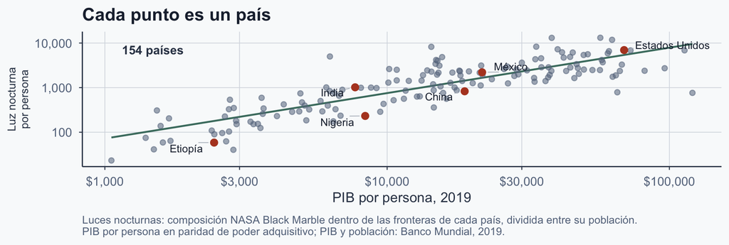

**Los países más ricos tienden a brillar más.** Los puntos suben juntos casi en línea recta.

**Y aquí está el punto:** un gobierno escribe sus propias cifras de PIB. No escribe las luces.

**Pero cuidado.** Esto es *ricos contra pobres, hoy*. Todavía no te dice quién está exagerando.

## Un número que el gobierno no puede apagar

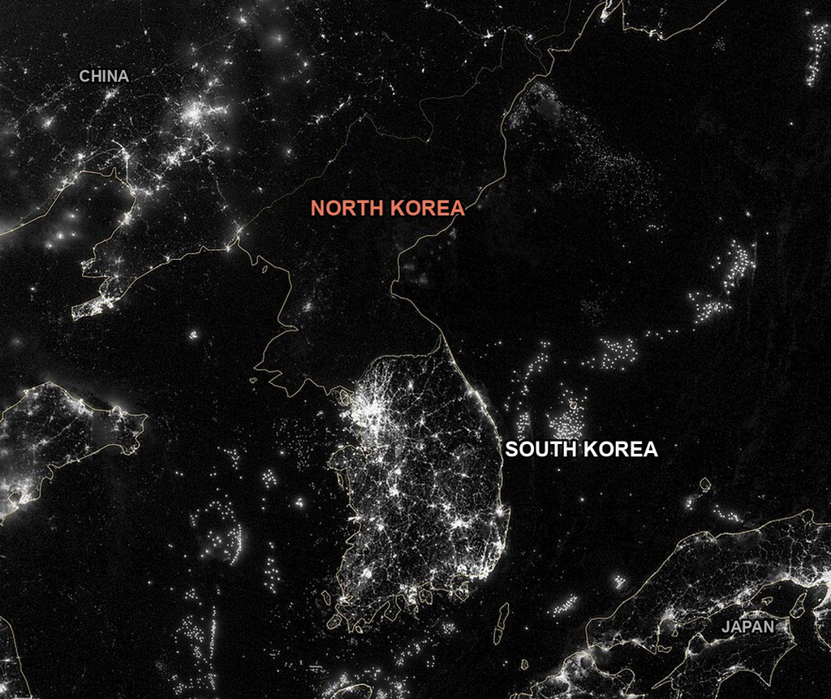

- Un gobierno reporta **su propio** PIB. No opera el satélite
- Así que pon las dos cosas lado a lado: cuando las luces de un país se encienden más, ¿cuánto crecimiento reporta ese año?
- Martinez lo hace para **184 países**, de 1992 a 2013, comparando a cada país consigo mismo a lo largo del tiempo
- **La prueba:** ¿el mismo aumento de brillo compra *más* crecimiento reportado en una autocracia que en una democracia?

Imagen: NASA Earth Observatory, VIIRS, 2012 — qué tan iluminados están los lugares, no evidencia de que algún gobierno haya falsificado sus cifras. Las luces aproximan la actividad; no son el PIB. Fuente: Martinez (2022).

## Las luces y los libros no coinciden

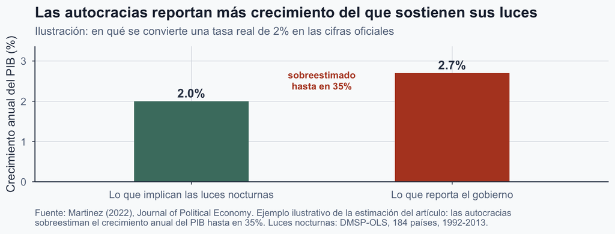

## ¿Qué aprendimos?

1. **México — ¿puede un algoritmo encontrar los contratos?** Sí: seis veces mejor que el azar en lo alto de la lista. Nunca se usó en una auditoría real, así que no sabemos si bajó la corrupción.
2. **India — ¿y si los medidos aprenden la medida?** El registro mejoró mucho más que los campos. De cada 100 incendios que salieron del conteo, unos 22 de verdad se evitaron.
3. **Autocracias — ¿unos datos externos pueden sorprender la exageración?** Sí, en el patrón: la misma luz compra más crecimiento reportado bajo autocracia. Sorprenderla no es detenerla.

**Todas las respuestas son *sí, pero*.** Los tres casos produjeron información nueva. En ninguno fue suficiente, por sí sola.

> La tecnología puede volver los actos indebidos mucho más fáciles de **detectar**. Que además los vuelva *menos frecuentes* depende de quién tenga el **incentivo** y el **poder** de actuar.

## Referencias

Adam, I., & Fazekas, M. (2021). Are emerging technologies helping win the fight against corruption? A review of the state of evidence. *Information Economics and Policy*, *57*, 100950. https://doi.org/10.1016/j.infoecopol.2021.100950

Bauhr, M., Czibik, Á., de Fine Licht, J., & Fazekas, M. (2020). Lights on the shadows of public procurement: Transparency as an antidote to corruption. *Governance*, *33*(3), 495–523. https://doi.org/10.1111/gove.12432

Beraja, M., Kao, A., Yang, D. Y., & Yuchtman, N. (2023). AI-tocracy. *The Quarterly Journal of Economics*, *138*(3), 1349–1402. https://doi.org/10.1093/qje/qjad012

Dasgupta, A. (2026). *Hidden fires: Real versus measured performance in bureaucracies* [Documento de trabajo]. University of California, Merced.

## Referencias (continuación)

Fazekas, M., Tóth, I. J., & King, L. P. (2016). An objective corruption risk index using public procurement data. *European Journal on Criminal Policy and Research*, *22*(3), 369–397. https://doi.org/10.1007/s10610-016-9308-z

Klitgaard, R. (1988). *Controlling corruption*. University of California Press.

Martinez, L. R. (2022). How much should we trust the dictator’s GDP growth estimates? *Journal of Political Economy*, *130*(10), 2731–2769. https://doi.org/10.1086/720458

Medina-Hernández, M., Kertész, J., & Fazekas, M. (2026). Learning from sanctioned government suppliers: A machine learning and network science approach to detecting fraud and corruption in Mexico. *Scientific Reports*, *16*(1), 22382. https://doi.org/10.1038/s41598-026-48873-w